# Titanic Survival Prediction

#### Remove:

- PassengerId, Ticket since they are rolling number
- Name - note: maybe can find more information about their socioeconomical status and background from their names but would need more expert knowledge about the country's and period's

#### Engineer:

- SibSp and Parch since they are highly collinear
  - Number of Family onboard
  - Flag for has family onboard or not

#### Select

- PClass
- Sex
  - to convert into binary values
- Age
  - to convert into ordinal values?
- Embarked
  - to convert into ordinal values
- Cabin
  - to convert into numerical based on Alphabet representing Deck A to G
  - https://www.encyclopedia-titanica.org/titanic-deckplans/a-deck.html
- Fare

```python
def computeFamilyFeatures(df):
    df["Num_Family"] = df["SibSp"] + df["Parch"]

    df.loc[df["Num_Family"] == 0, "Has_Family"] = 0
    df.loc[df["Num_Family"] > 0, "Has_Family"] = 1
#     df.head()
    return df
```

```python
def fillCabinNan(df):
    df['Cabin'] = df['Cabin'].fillna('U')
    return df
```

```python
# Map and replace values
def replaceFeaturesValues(df):
    gender = {'male': 0, 'female': 1}
    embarked = {"S": 0, "C": 1, "Q": 2}
    cabin = {"A": 0, "B": 1, "C": 2, "D": 3, "E": 4, "F":5, "G":6, "U": 7}

    df["Sex"].replace(gender, inplace=True)
    df["Embarked"].replace(embarked, inplace=True)
    df['Cabin'] = df['Cabin'].str[0].map(cabin)
    df.head()

    return df
```

```python
def normaliseTitles(df):
    titlesMap = {
        "Capt":       "Officer",
        "Col":        "Officer",
        "Major":      "Officer",
        "Jonkheer":   "Nobility",
        "Don":        "Nobility",
        "Sir" :       "Nobility",
        "Dr":         "Officer",
        "Rev":        "Officer",
        "the Countess":"Nobility",
        "Dona":       "Nobility",
        "Mme":        "Mrs",
        "Mlle":       "Miss",
        "Ms":         "Mrs",
        "Mr" :        "Mr",
        "Mrs" :       "Mrs",
        "Miss" :      "Miss",
        "Master" :    "Master",
        "Lady" :      "Nobility"
    }

    df['Title'].map(titlesMap)

    return df
```

```python
train_set = computeFamilyFeatures(train_set)
train_set = fillCabinNan(train_set)
train_set = replaceFeaturesValues(train_set)
# extractTitleFromName(train_set) is done in EDA
train_set = normaliseTitles(train_set)


# remove features and keep the following:
train_set = train_set[['Survived', 'Pclass', 'Sex', 'Age', 'Fare', 'Cabin', 'Embarked', 'Num_Family', 'Has_Family', 'Title']]

train_set.head()
```

|  | Survived | Pclass | Sex | Age | Fare | Cabin | Embarked | Num_Family | Has_Family | Title |
| --- | --- | --- | --- | --- | --- | --- | --- | --- | --- | --- |
| 0 | 0 | 3 | 0 | 22.0 | 7.2500 | 7.0 | 0.0 | 1 | 1.0 | Mr |
| 1 | 1 | 1 | 1 | 38.0 | 71.2833 | 2.0 | 1.0 | 1 | 1.0 | Mrs |
| 2 | 1 | 3 | 1 | 26.0 | 7.9250 | 7.0 | 0.0 | 0 | 0.0 | Miss |
| 3 | 1 | 1 | 1 | 35.0 | 53.1000 | 2.0 | 0.0 | 1 | 1.0 | Mrs |
| 4 | 0 | 3 | 0 | 35.0 | 8.0500 | 7.0 | 0.0 | 0 | 0.0 | Mr |

#### Feature Engineering For Test Set

```python
test_set.info()
```

```
<class 'pandas.core.frame.DataFrame'>
RangeIndex: 418 entries, 0 to 417
Data columns (total 11 columns):
PassengerId    418 non-null int64
Pclass         418 non-null int64
Name           418 non-null object
Sex            418 non-null object
Age            332 non-null float64
SibSp          418 non-null int64
Parch          418 non-null int64
Ticket         418 non-null object
Fare           417 non-null float64
Cabin          91 non-null object
Embarked       418 non-null object
dtypes: float64(2), int64(4), object(5)
memory usage: 36.0+ KB
```

```python
# test_set.Cabin.value_counts()
test_set.head()
```

|  | PassengerId | Pclass | Name | Sex | Age | SibSp | Parch | Ticket | Fare | Cabin | Embarked |
| --- | --- | --- | --- | --- | --- | --- | --- | --- | --- | --- | --- |
| 0 | 892 | 3 | Kelly, Mr. James | male | 34.5 | 0 | 0 | 330911 | 7.8292 | NaN | Q |
| 1 | 893 | 3 | Wilkes, Mrs. James (Ellen Needs) | female | 47.0 | 1 | 0 | 363272 | 7.0000 | NaN | S |
| 2 | 894 | 2 | Myles, Mr. Thomas Francis | male | 62.0 | 0 | 0 | 240276 | 9.6875 | NaN | Q |
| 3 | 895 | 3 | Wirz, Mr. Albert | male | 27.0 | 0 | 0 | 315154 | 8.6625 | NaN | S |
| 4 | 896 | 3 | Hirvonen, Mrs. Alexander (Helga E Lindqvist) | female | 22.0 | 1 | 1 | 3101298 | 12.2875 | NaN | S |

```python
num_missing_values = test_set.isnull().sum().sort_values(ascending=False)
# print(num_missing_values)

percentage_missing = round(test_set.isnull().sum()/len(test_set)* 100, 1).sort_values(ascending=False)
# print(percentage_missing)

missing_data = pd.concat([num_missing_values, percentage_missing], axis=1, keys=['Num Missing', '%'])
missing_data.head(5)
```

|  | Num Missing | % |
| --- | --- | --- |
| Cabin | 327 | 78.2 |
| Age | 86 | 20.6 |
| Fare | 1 | 0.2 |
| Embarked | 0 | 0.0 |
| Ticket | 0 | 0.0 |

```python
# test_set = test.copy()
test_set = computeFamilyFeatures(test_set)
test_set = fillCabinNan(test_set)
test_set = replaceFeaturesValues(test_set)
test_set = extractTitleFromName(test_set)
test_set = normaliseTitles(test_set)

test_set = test_set[['Pclass', 'Sex', 'Age', 'Fare', 'Cabin', 'Embarked', 'Num_Family', 'Has_Family', 'Title']]
test_set.head()
```

|  | Pclass | Sex | Age | Fare | Cabin | Embarked | Num_Family | Has_Family | Title |
| --- | --- | --- | --- | --- | --- | --- | --- | --- | --- |
| 0 | 3 | 0 | 34.5 | 7.8292 | 7 | 2 | 0 | 0.0 | Mr |
| 1 | 3 | 1 | 47.0 | 7.0000 | 7 | 0 | 1 | 1.0 | Mrs |
| 2 | 2 | 0 | 62.0 | 9.6875 | 7 | 2 | 0 | 0.0 | Mr |
| 3 | 3 | 0 | 27.0 | 8.6625 | 7 | 0 | 0 | 0.0 | Mr |
| 4 | 3 | 1 | 22.0 | 12.2875 | 7 | 0 | 2 | 1.0 | Mrs |

#### Model Building and Evaluation

```python
from sklearn.impute import SimpleImputer
from sklearn.pipeline import Pipeline

from sklearn.linear_model import LogisticRegression
from sklearn.tree import DecisionTreeClassifier
from sklearn.ensemble import RandomForestClassifier

from sklearn.model_selection import RandomizedSearchCV, GridSearchCV, cross_val_score
from sklearn.metrics import auc, accuracy_score, confusion_matrix, roc_curve, precision_score, recall_score, f1_score, auc, precision_recall_curve
from sklearn.compose import ColumnTransformer
from sklearn.preprocessing import StandardScaler
from sklearn.decomposition import PCA
```

```python
# Impute for Training Set
age_imputer = SimpleImputer(missing_values=np.nan, strategy='median')
embarked_imputer = SimpleImputer(missing_values=np.nan, strategy='most_frequent')
fare_imputer = SimpleImputer(missing_values=np.nan, strategy='median')
```

```python
col_transformer = ColumnTransformer(transformers=[
        ('age_imputer', age_imputer, ['Age']),
        ('embarked_imputer', embarked_imputer, ['Embarked']),
        ('fare_imputer', fare_imputer, ['Fare'])], remainder='drop')

preprocessor = Pipeline(steps=[('col_trans', col_transformer)])
```

```python
train_set.head()
train_set.columns
```

```
Index(['Survived', 'Pclass', 'Sex', 'Age', 'Fare', 'Cabin', 'Embarked',
       'Num_Family', 'Has_Family', 'Title'],
      dtype='object')
```

```python
X_train = train_set[['Pclass', 'Sex', 'Age', 'Fare', 'Cabin', 'Embarked', 'Num_Family', 'Has_Family']]
y_train = train_set['Survived']
X_train.head()
```

|  | Pclass | Sex | Age | Fare | Cabin | Embarked | Num_Family | Has_Family |
| --- | --- | --- | --- | --- | --- | --- | --- | --- |
| 0 | 3 | 0 | 22.0 | 7.2500 | 7.0 | 0.0 | 1 | 1.0 |
| 1 | 1 | 1 | 38.0 | 71.2833 | 2.0 | 1.0 | 1 | 1.0 |
| 2 | 3 | 1 | 26.0 | 7.9250 | 7.0 | 0.0 | 0 | 0.0 |
| 3 | 1 | 1 | 35.0 | 53.1000 | 2.0 | 0.0 | 1 | 1.0 |
| 4 | 3 | 0 | 35.0 | 8.0500 | 7.0 | 0.0 | 0 | 0.0 |

```python
preprocessor.fit(X_train)
X_train_preprocessed = preprocessor.transform(X_train)
X_train_preprocessed = pd.DataFrame(data=X_train_preprocessed, index=X_train.index, columns=['Age', 'Embarked', 'Fare'])

X_train_preprocessed = pd.concat([X_train_preprocessed, X_train[['Cabin', 'Pclass', 'Sex', 'Num_Family', 'Has_Family']]], axis=1)
X_train_preprocessed = pd.get_dummies(X_train_preprocessed, columns=['Cabin', 'Embarked','Pclass', 'Sex', 'Has_Family'])
X_train_preprocessed
```

|  | Age | Fare | Num_Family | Cabin_0.0 | Cabin_1.0 | Cabin_2.0 | Cabin_3.0 | Cabin_4.0 | Cabin_5.0 | Cabin_6.0 | ... | Embarked_0.0 | Embarked_1.0 | Embarked_2.0 | Pclass_1 | Pclass_2 | Pclass_3 | Sex_0 | Sex_1 | Has_Family_0.0 | Has_Family_1.0 |
| --- | --- | --- | --- | --- | --- | --- | --- | --- | --- | --- | --- | --- | --- | --- | --- | --- | --- | --- | --- | --- | --- |
| 0 | 22.0 | 7.2500 | 1 | 0 | 0 | 0 | 0 | 0 | 0 | 0 | ... | 1 | 0 | 0 | 0 | 0 | 1 | 1 | 0 | 0 | 1 |
| 1 | 38.0 | 71.2833 | 1 | 0 | 0 | 1 | 0 | 0 | 0 | 0 | ... | 0 | 1 | 0 | 1 | 0 | 0 | 0 | 1 | 0 | 1 |
| 2 | 26.0 | 7.9250 | 0 | 0 | 0 | 0 | 0 | 0 | 0 | 0 | ... | 1 | 0 | 0 | 0 | 0 | 1 | 0 | 1 | 1 | 0 |
| 3 | 35.0 | 53.1000 | 1 | 0 | 0 | 1 | 0 | 0 | 0 | 0 | ... | 1 | 0 | 0 | 1 | 0 | 0 | 0 | 1 | 0 | 1 |
| 4 | 35.0 | 8.0500 | 0 | 0 | 0 | 0 | 0 | 0 | 0 | 0 | ... | 1 | 0 | 0 | 0 | 0 | 1 | 1 | 0 | 1 | 0 |
| ... | ... | ... | ... | ... | ... | ... | ... | ... | ... | ... | ... | ... | ... | ... | ... | ... | ... | ... | ... | ... | ... |
| 886 | 27.0 | 13.0000 | 0 | 0 | 0 | 0 | 0 | 0 | 0 | 0 | ... | 1 | 0 | 0 | 0 | 1 | 0 | 1 | 0 | 1 | 0 |
| 887 | 19.0 | 30.0000 | 0 | 0 | 1 | 0 | 0 | 0 | 0 | 0 | ... | 1 | 0 | 0 | 1 | 0 | 0 | 0 | 1 | 1 | 0 |
| 888 | 28.0 | 23.4500 | 3 | 0 | 0 | 0 | 0 | 0 | 0 | 0 | ... | 1 | 0 | 0 | 0 | 0 | 1 | 0 | 1 | 0 | 1 |
| 889 | 26.0 | 30.0000 | 0 | 0 | 0 | 1 | 0 | 0 | 0 | 0 | ... | 0 | 1 | 0 | 1 | 0 | 0 | 1 | 0 | 1 | 0 |
| 890 | 32.0 | 7.7500 | 0 | 0 | 0 | 0 | 0 | 0 | 0 | 0 | ... | 0 | 0 | 1 | 0 | 0 | 1 | 1 | 0 | 1 | 0 |

891 rows × 21 columns

```python
X_test_preprocessed = preprocessor.transform(test_set)
X_test_preprocessed = pd.DataFrame(data=X_test_preprocessed, index=test_set.index, columns=['Age', 'Embarked', 'Fare'])

X_test_preprocessed = pd.concat([X_test_preprocessed, test_set[['Cabin', 'Pclass', 'Sex', 'Num_Family', 'Has_Family']]], axis=1)
X_test_preprocessed = pd.get_dummies(X_test_preprocessed, columns=['Cabin', 'Embarked','Pclass', 'Sex', 'Has_Family'])
X_test_preprocessed
```

|  | Age | Fare | Num_Family | Cabin_0 | Cabin_1 | Cabin_2 | Cabin_3 | Cabin_4 | Cabin_5 | Cabin_6 | ... | Embarked_0.0 | Embarked_1.0 | Embarked_2.0 | Pclass_1 | Pclass_2 | Pclass_3 | Sex_0 | Sex_1 | Has_Family_0.0 | Has_Family_1.0 |
| --- | --- | --- | --- | --- | --- | --- | --- | --- | --- | --- | --- | --- | --- | --- | --- | --- | --- | --- | --- | --- | --- |
| 0 | 34.5 | 7.8292 | 0 | 0 | 0 | 0 | 0 | 0 | 0 | 0 | ... | 0 | 0 | 1 | 0 | 0 | 1 | 1 | 0 | 1 | 0 |
| 1 | 47.0 | 7.0000 | 1 | 0 | 0 | 0 | 0 | 0 | 0 | 0 | ... | 1 | 0 | 0 | 0 | 0 | 1 | 0 | 1 | 0 | 1 |
| 2 | 62.0 | 9.6875 | 0 | 0 | 0 | 0 | 0 | 0 | 0 | 0 | ... | 0 | 0 | 1 | 0 | 1 | 0 | 1 | 0 | 1 | 0 |
| 3 | 27.0 | 8.6625 | 0 | 0 | 0 | 0 | 0 | 0 | 0 | 0 | ... | 1 | 0 | 0 | 0 | 0 | 1 | 1 | 0 | 1 | 0 |
| 4 | 22.0 | 12.2875 | 2 | 0 | 0 | 0 | 0 | 0 | 0 | 0 | ... | 1 | 0 | 0 | 0 | 0 | 1 | 0 | 1 | 0 | 1 |
| ... | ... | ... | ... | ... | ... | ... | ... | ... | ... | ... | ... | ... | ... | ... | ... | ... | ... | ... | ... | ... | ... |
| 413 | 28.0 | 8.0500 | 0 | 0 | 0 | 0 | 0 | 0 | 0 | 0 | ... | 1 | 0 | 0 | 0 | 0 | 1 | 1 | 0 | 1 | 0 |
| 414 | 39.0 | 108.9000 | 0 | 0 | 0 | 1 | 0 | 0 | 0 | 0 | ... | 0 | 1 | 0 | 1 | 0 | 0 | 0 | 1 | 1 | 0 |
| 415 | 38.5 | 7.2500 | 0 | 0 | 0 | 0 | 0 | 0 | 0 | 0 | ... | 1 | 0 | 0 | 0 | 0 | 1 | 1 | 0 | 1 | 0 |
| 416 | 28.0 | 8.0500 | 0 | 0 | 0 | 0 | 0 | 0 | 0 | 0 | ... | 1 | 0 | 0 | 0 | 0 | 1 | 1 | 0 | 1 | 0 |
| 417 | 28.0 | 22.3583 | 2 | 0 | 0 | 0 | 0 | 0 | 0 | 0 | ... | 0 | 1 | 0 | 0 | 0 | 1 | 1 | 0 | 0 | 1 |

418 rows × 21 columns

```python
X_test_preprocessed.columns
```

```
Index(['Age', 'Fare', 'Num_Family', 'Cabin_0', 'Cabin_1', 'Cabin_2', 'Cabin_3',
       'Cabin_4', 'Cabin_5', 'Cabin_6', 'Cabin_7', 'Embarked_0.0',
       'Embarked_1.0', 'Embarked_2.0', 'Pclass_1', 'Pclass_2', 'Pclass_3',
       'Sex_0', 'Sex_1', 'Has_Family_0.0', 'Has_Family_1.0'],
      dtype='object')
```

```python
import xgboost as xgb
est_xgb = Pipeline([('xgb', xgb.XGBClassifier())])

xgb_grid = {'xgb__objective' : 'binary:logistic',
            'xgb__max_depth': [5, 10, 25],
            'xgb__n_estimators': [10, 25, 40, 65, 100],
            'xgb__seed': [1234]
          }

dtrainMatrix = xgb.DMatrix(data=X_train_preprocessed, label=y_train)

cv_results = xgb.cv(dtrain=dtrainMatrix , params=xgb_grid, nfold=10, num_boost_round=10, metrics="error", as_pandas=True)
print("Accuracy: %f" %((1-cv_results["test-error-mean"]).iloc[-1]))

# estimators.append(est_xgb)

# hyperparams.append(xgb_grid)
```

```
Accuracy: 0.829388
```

```python
estimators = []
hyperparams = []
```

```python
est_lr = Pipeline([('lr', LogisticRegression())])

lr_grid = {'lr__C': [0.01, 0.1, 0.5, 1.0, 2.0],
           'lr__random_state': [1234],
           'lr__solver': ['newton-cg', 'lbfgs', 'liblinear', 'sag', 'saga'],
           'lr__max_iter': [100],
          }

estimators.append(est_lr)

hyperparams.append(lr_grid)
```

```python
est_lr = Pipeline([('scaler', StandardScaler()), ('pca', PCA()), ('lr', LogisticRegression())])

lr_grid = {'pca__n_components': [2, 3, 5, 7],
           'lr__C': [0.01, 0.1, 0.5, 1.0, 2.0],
           'lr__random_state': [1234],
           'lr__solver': ['newton-cg', 'lbfgs', 'liblinear', 'sag', 'saga'],
           'lr__max_iter': [100],
          }

estimators.append(est_lr)

hyperparams.append(lr_grid)
```

```python
est_dtc = Pipeline([('scaler', StandardScaler()),('pca', PCA()),('dtc', DecisionTreeClassifier())])


dtc_grid = {
            'pca__n_components': [2, 3, 5, 7],
            'dtc__criterion':['gini', 'entropy'],
            'dtc__max_depth': [2, 4, 6, 8, 10],
            'dtc__max_features': ['sqrt', 'log2', None],
            'dtc__random_state': [1234],
            'dtc__class_weight': ['balanced',None]
            }

estimators.append(est_dtc)

hyperparams.append(dtc_grid)
```

```python
est_rfc = Pipeline([('scaler', StandardScaler()),('pca', PCA()), ('rfc', RandomForestClassifier())])

rfc_grid = {'pca__n_components': [2, 3, 5, 7],
            'rfc__n_estimators': [100],
            'rfc__criterion': ['gini', 'entropy'],
            'rfc__max_depth': [2, 4, 6, 8, 10],
            'rfc__max_features': ['sqrt', 'log2', None],
            'rfc__oob_score' : [False],
            'rfc__random_state': [1234]
}

estimators.append(est_rfc)

hyperparams.append(rfc_grid)
```

```python
all_estimators = []
all_scores = []

for index, est in enumerate(estimators):
    estimator = GridSearchCV(est, hyperparams[index], cv=5, scoring='accuracy')
    estimator.fit(X_train_preprocessed, y_train)
    print("For Est", index+1)
    print('Best hyperparameter:', estimator.best_params_)
    all_estimators.append(estimator)

    # Evaluate the four best estimators over 5-fold cross validation on the training data.
    # Print the mean and std of AUC over the 5-folds for each best estimator.
    scores = cross_val_score(estimator.best_estimator_, X_train_preprocessed, y_train, cv=5, scoring='roc_auc')
    print('AUC = {:.3f} mean  +/-  {:.3f} std'.format(scores.mean(), scores.std()))
    print("")
    all_scores.append(scores)
```

```
For Est 1
Best hyperparameter: {'lr__C': 0.1, 'lr__max_iter': 100, 'lr__random_state': 1234, 'lr__solver': 'lbfgs'}
AUC = 0.856 mean  +/-  0.016 std

For Est 2
Best hyperparameter: {'lr__C': 0.01, 'lr__max_iter': 100, 'lr__random_state': 1234, 'lr__solver': 'newton-cg', 'pca__n_components': 7}
AUC = 0.842 mean  +/-  0.020 std
```

[output not shown]

[output not shown]

```python
all_scores
```

```
[array([0.83768116, 0.84183136, 0.85755348, 0.85741979, 0.88430923]),
 array([0.82002635, 0.81534914, 0.86102941, 0.85354278, 0.8609687 ]),
 array([0.82951252, 0.77681159, 0.85093583, 0.83215241, 0.82575553]),
 array([0.81475626, 0.80619236, 0.87453209, 0.86410428, 0.89422558])]
```

```python
performances = pd.DataFrame({'Estimators': all_estimators, 'Scores': all_scores, 'AUC Mean': [score.mean() for score in all_scores], 'AUC Std Dev': [score.std() for score in all_scores]})
performances
```

|  | Estimators | Scores | AUC Mean | AUC Std Dev |
| --- | --- | --- | --- | --- |
| 0 | GridSearchCV(cv=5, error_score='raise-deprecat... | [0.8376811594202898, 0.8418313570487483, 0.857... | 0.855759 | 0.016382 |
| 1 | GridSearchCV(cv=5, error_score='raise-deprecat... | [0.820026350461133, 0.8153491436100133, 0.8610... | 0.842183 | 0.020239 |
| 2 | GridSearchCV(cv=5, error_score='raise-deprecat... | [0.8295125164690382, 0.7768115942028986, 0.850... | 0.823034 | 0.024688 |
| 3 | GridSearchCV(cv=5, error_score='raise-deprecat... | [0.8147562582345191, 0.8061923583662715, 0.874... | 0.850762 | 0.034395 |

#### Further Evaluation of Classifier

```python
estimator = performances['Estimators'][0].best_estimator_
predictions = estimator.predict(X_train_preprocessed)

cm = confusion_matrix(y_train, predictions, labels=[1, 0])
cm = pd.DataFrame(
    cm,
    index=['True: Survived', 'True: Not Survived'],
    columns=['Pred: Survived', 'Pred: Not Survived']
)
cm
```

[output not shown]

```python
precision = precision_score(y_train, predictions)
print("The precision of the classifier is {:.2%}".format(precision))

# recall
recall = recall_score(y_train, predictions)
print("The recall of the classifier is {:.2%}".format(recall))

# recall
f1 = f1_score(y_train, predictions, labels=['Survived'])
print("The f1 score of the classifier is {:.2%}".format(f1))
```

```
The precision of the classifier is 79.15%
The recall of the classifier is 71.05%
The f1 score of the classifier is 74.88%
```

#### Intepretation

Based on f1 score of the "Survived", the weighted average of the precision and recall is 74.88%

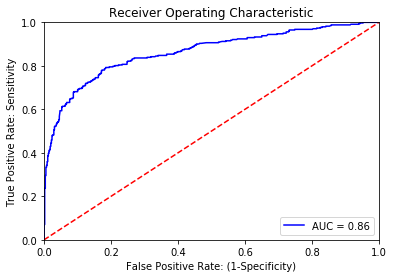

```python
def drawROC(estimator):
    y_prob = estimator.predict_proba(X_train_preprocessed) [:,1]
    fpr, tpr, threshold = roc_curve(y_train, y_prob)
    roc_auc = auc(fpr, tpr)

    plt.title('Receiver Operating Characteristic')
    plt.plot(fpr, tpr, 'b', label = 'AUC = %0.2f' % roc_auc)
    plt.legend(loc = 'lower right')
    plt.plot([0, 1], [0, 1],'r--')
    plt.xlim([0, 1])
    plt.ylim([0, 1])
    plt.ylabel('True Positive Rate: Sensitivity')
    plt.xlabel('False Positive Rate: (1-Specificity)')
    plt.show()

drawROC(estimator)
```

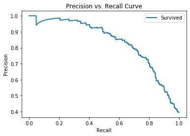

```python
def drawPrecisionRecallCurve(y_train, y_prob):
    precision, recall, _ = precision_recall_curve(y_train, y_prob)
    plt.plot(recall, precision, lw=2, label='Survived')

    plt.xlabel("Recall")
    plt.ylabel("Precision")
    plt.legend(loc="best")
    plt.title("Precision vs. Recall Curve")
    plt.show()

drawPrecisionRecallCurve(y_train, y_prob)
```

#### Submission of Predictions to Kaggle

```python
estimator = performances['Estimators'][0].best_estimator_
predictions = estimator.predict(X_test_preprocessed)
# predictions
```

```python
test_set = pd.read_csv(test_dir)
submission = pd.DataFrame({'PassengerId': test_set['PassengerId'], 'Survived': predictions})
submission
```

|  | PassengerId | Survived |
| --- | --- | --- |
| 0 | 892 | 0 |
| 1 | 893 | 0 |
| 2 | 894 | 0 |
| 3 | 895 | 0 |
| 4 | 896 | 1 |
| ... | ... | ... |
| 413 | 1305 | 0 |
| 414 | 1306 | 1 |
| 415 | 1307 | 0 |
| 416 | 1308 | 0 |
| 417 | 1309 | 0 |

418 rows × 2 columns

```python
submission.to_csv('predictions.csv', index = False)
```